# Exploratory data analysis of the Diabetes Risk dataset

Gurdeepak Sidhu  
November 28, 2020

# Summary of the data set

The dataset used for the analysis in the project is based on medical screening questions from the patients of Sylhet Diabetes Hospital in Bangladesh collected by M, IslamEmail, Rahatara Ferdousi, Sadikur Rahman and Yasmin Bushra (M and Bushra 2019). The dataset was sourced from the UCI Machine Learning Repository (Dua and Graff 2017) specifically [this file](https://archive.ics.uci.edu/ml/machine-learning-databases/00529/diabetes_data_upload.csv).

Each observation in the data set is a patient, and attributes corresponds to the medical screening questions asked such as age, sex, obesity and others. It includes the diagnosis for the patient (positive(Diabetic) or negative(Not Diabetic)), and the diagnosis was conducted and approved by a certified doctor. There are 520 observations in the data set, and 17 features. There are no observations with missing values in the data set. The number of observations in each classes are shown in the table below.

| Positive Diabetes | Negative Diabetes |
| --- | --- |
| 320 | 200 |

Table 1. Counts of observation for each class.

# Partition the data set into training and test sets

Before proceeding further, we will split the data such that 80% of observations are in the training and 20% of observations are in the test set. Below we list the counts of observations for each class:

| Data partition | Positive Diabetes | Negative Diabetes |
| --- | --- | --- |
| Training | 254 | 162 |
| Test | 66 | 38 |

Table 2. Counts of observation for each class for each data partition.

# Exploratory analysis on the training data set

To look at whether each of the predictors might be useful to predict the diabetes class, we plotted the barplots of each predictor based on the target class from the training data set and colored the distribution by class (Negative: blue and positive: orange). Since the dataset has mostly categorical features and one numeric feature (age), we created a separate histogram for the `age` feature. Based on the histogram of the categorical predictors it seems the variables such as partial paresis, polydipsia, sudden weight loss, and polyuria seems to be significant in predicting diabetes cases. We will pay a close attention to this variables in the predictive models trained.

Density plot for the `age` features in the Diabetes data set.

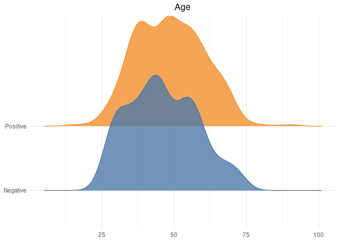

Figure 1. Distribution of training set age predictor for the Positive and Negative diabetes cases

Histogram for the categorical features(predictors) in the Diabetes data set.

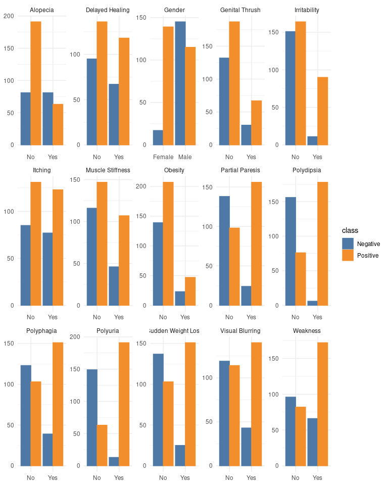

Figure 2. Distribution of training set predictors for the Positive and Negative diabetes cases

# References

Dua, Dheeru, and Casey Graff. 2017. “UCI Machine Learning Repository.” University of California, Irvine, School of Information; Computer Sciences. http://archive.ics.uci.edu/ml.

M, Rahatara Ferdousi, IslamEmail, and Yasmin Bushra. 2019. “Likelihood prediction of diabetes at early stage using data mining techniques.” In *Computer Vision and Machine Intelligence in Medical Image Analysis*, edited by Debanjan Konar Mousumi Gupta and Siddhartha Bhattacharyya, 1st ed., 113–25. International Society for Optics; Photonics; Springer.